# analiza danych - samochody

Dominik Bartosiak, Damian Damięcki, Mikołaj Kustusz

2025-11-22

# Wstęp

Celem niniejszego raportu jest analiza danych dotyczących cen samochodów w Polsce. Dane zostały pozyskane z platformy Kaggle i zawierają informacje na temat różnych modeli samochodów, ich cech oraz cen rynkowych. Analiza ma na celu zrozumienie czynników wpływających na ceny samochodów oraz identyfikację wzorców i trendów w danych.

## Opis danych

Celem zbioru jest umożliwienie analizy cen, cech technicznych, profilu ofert i trendów rynkowych dotyczących samochodów używanych i nowych dostępnych na polskim rynku.

### Pytania badawcze

1. **Jakie są średnie ceny samochodów w zależności od marki i modelu?**
2. **Które cechy samochodów (np. rok produkcji, przebieg, moc silnika, rodzaj paliwa) mają największy wpływ na cenę pojazdu?**
3. **Jak zmieniają się ceny samochodów w zależności od roku produkcji? Czy starsze samochody tanieją liniowo czy nieliniowo?**
4. **Czy istnieją różnice w cenach samochodów w zależności od typu pojazdu (np. sedan, SUV, hatchback, kombi)?**
5. **Jak przebieg pojazdu wpływa na jego cenę i czy wpływ ten różni się między markami?**
6. **Czy rodzaj paliwa (benzyna, diesel, LPG, hybryda, elektryczny) wpływa na cenę?**

## 2.1 Braki danych

```r
dane %>% select(-"...1")
```

```
## # A tibble: 117,927 × 10
##    mark  model generation_name  year mileage vol_engine fuel   city     province
##    <chr> <chr> <chr>           <dbl>   <dbl>      <dbl> <chr>  <chr>    <chr>
##  1 opel  combo gen-d-2011       2015  139568       1248 Diesel Janki    Mazowie…
##  2 opel  combo gen-d-2011       2018   31991       1499 Diesel Katowice Śląskie
##  3 opel  combo gen-d-2011       2015  278437       1598 Diesel Brzeg    Opolskie
##  4 opel  combo gen-d-2011       2016   47600       1248 Diesel Korfant… Opolskie
##  5 opel  combo gen-d-2011       2014  103000       1400 CNG    Tarnows… Śląskie
##  6 opel  combo gen-d-2011       2017  121203       1598 Diesel Warszawa Mazowie…
##  7 opel  combo gen-d-2011       2017  119965       1248 Diesel Wrocław  Dolnośl…
##  8 opel  combo gen-d-2011       2016  201658       1248 Diesel Lublin   Lubelsk…
##  9 opel  combo gen-d-2011       2014  178666       1598 Diesel Złotów   Wielkop…
## 10 opel  combo gen-d-2011       2015  113000       1248 Diesel Strzyżew Mazowie…
## # ℹ 117,917 more rows
## # ℹ 1 more variable: price <dbl>
```

```r
procent <- prop_complete_var(dane) * 100
```

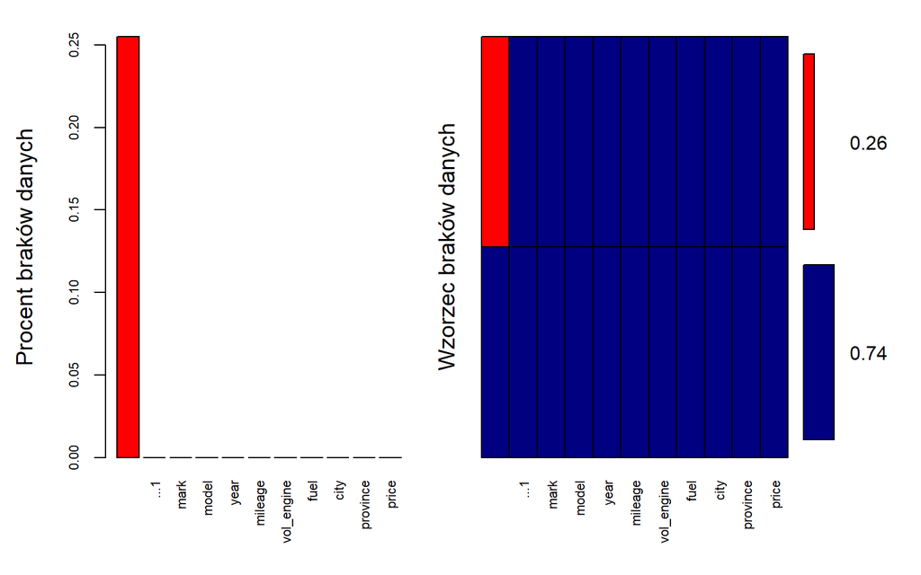

```
##
##  Variables sorted by number of missings:
##         Variable     Count
##  generation_name 0.2551155
##             ...1 0.0000000
##             mark 0.0000000
##            model 0.0000000
##             year 0.0000000
##          mileage 0.0000000
##       vol_engine 0.0000000
##             fuel 0.0000000
##             city 0.0000000
##         province 0.0000000
##            price 0.0000000
```

```r
VIM::aggr(dane, col=c('navyblue','red'), numbers=TRUE, sortVars=TRUE, labels=names(dane), cex.axis=.7, gap=3, ylab=c("Procent braków danych","Wzorzec braków danych"))
```

## Imputacje danych

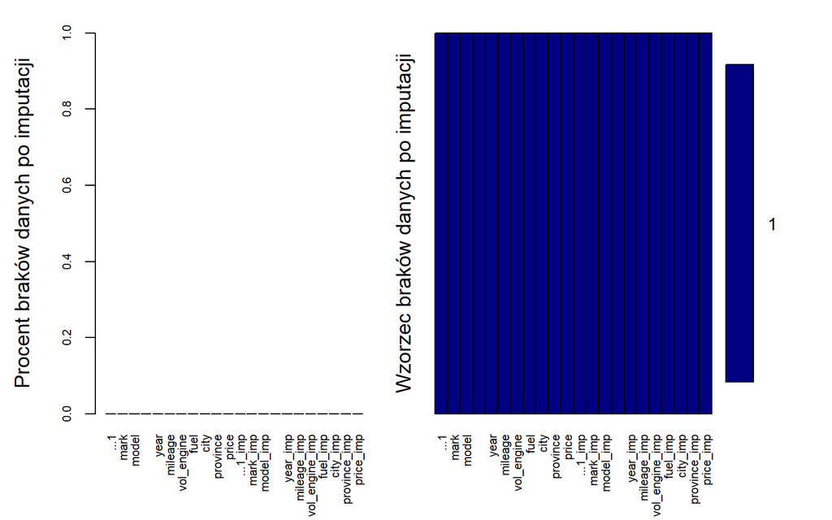

```
##
##  Variables sorted by number of missings:
##             Variable Count
##                 ...1     0
##                 mark     0
##                model     0
##      generation_name     0
##                 year     0
##              mileage     0
##           vol_engine     0
##                 fuel     0
##                 city     0
##             province     0
##                price     0
##             ...1_imp     0
##             mark_imp     0
##            model_imp     0
##  generation_name_imp     0
##             year_imp     0
##          mileage_imp     0
##       vol_engine_imp     0
##             fuel_imp     0
##             city_imp     0
##         province_imp     0
##            price_imp     0
```

```r
dane_imp <- hotdeck(dane)
VIM::aggr(dane_imp, col=c('navyblue','red'), numbers=TRUE, sortVars=TRUE, labels=names(dane_imp), cex.axis=.7, gap=3, ylab=c("Procent braków danych po imputacji","Wzorzec braków danych po imputacji"))
```

Po imputacji danych za pomocą metody hotdeck, wszystkie braki danych zostały uzupełnione.

## 2.2 Walidacja danych

## Reguły

Rozpatrzmy następujący zbiór danych. Co widzisz w początkowych wierszach?

```r
data(dane_imp)
head(dane_imp[3:7],3)
```

```
##   model generation_name year mileage vol_engine
## 1 combo      gen-d-2011 2015  139568       1248
## 2 combo      gen-d-2011 2018   31991       1499
## 3 combo      gen-d-2011 2015  278437       1598
```

```r
# dodajmy ID
dane_imp$rec_id <- sprintf("%03d",1:nrow(dane_imp))

rules <- validator(
  price >= 0
  , year > 0 & year < 2026
  , mileage >= 0
  , fuel %in% c("Diesel", "CNG", "Gasoline", "Hybrid", "Electric", "LPG")
)

cf <- confront(dane_imp, rules, key="rec_id")
summary(cf)
```

```
##   name  items passes fails nNA error warning
## 1   V1 117927 117927     0   0 FALSE   FALSE
## 2   V2 117927 117927     0   0 FALSE   FALSE
## 3   V3 117927 117927     0   0 FALSE   FALSE
## 4   V4 117927 117927     0   0 FALSE   FALSE
##                                                               expression
## 1                                                    price - 0 >= -1e-08
## 2                                                 year > 0 & year < 2026
## 3                                                  mileage - 0 >= -1e-08
## 4 fuel %vin% c("Diesel", "CNG", "Gasoline", "Hybrid", "Electric", "LPG")
```

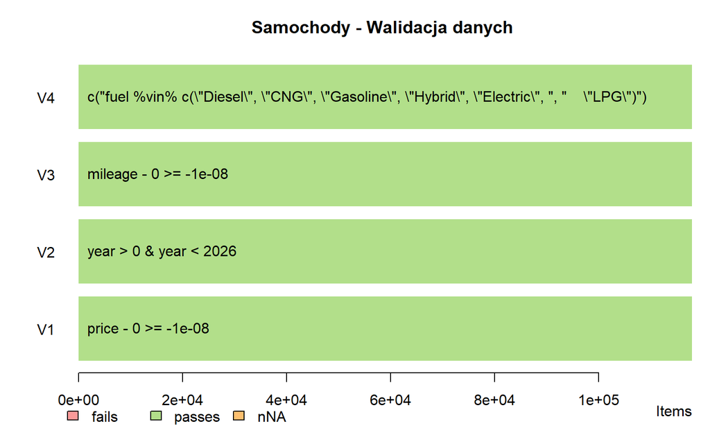

```r
barplot(cf, main="Samochody - Walidacja danych")
```

```r
#as.data.frame(cf) %>% head()
```

Wszystkie dane są poprawne zgodnie z ustalonymi regułami walidacji.